# Model output test

### 3.4.2 Multi-simulation’s extraction test

#### 3.4.2.1 First setup : 1 DoE, Usms from 100K to 500K and 289 Dates

```r
Usms <- c(100000,200000,300000,400000,500000)
li <- list()
tb <- list()
for (index in Usms) {

  multi_tb <- create_tibble3(USM_list_1996,1,index,sim_data_289)
  multi_li <- create_list2(USM_list_1996,1,index,sim_data_289)

  benchmark_multi <- microbenchmark(li = list_get_usm_names_and_var_values2(multi_li,1,"resmes","1996/01/05"),
                                  tb = tibble_get_usm_names_and_var_values(multi_tb,1,"resmes","1996-01-05"),
                                  times = 10)
  print(benchmark_multi)
  if (index == 100000) {
    li <- summary(benchmark_multi)$median[1]
    tb <- summary(benchmark_multi)$median[2]
  }
  else {
    li <- append(li,summary(benchmark_multi)$median[1])
    tb <- append(tb,summary(benchmark_multi)$median[2])
  }
  print(ggplot2::autoplot(benchmark_multi))
  gc()
}
df <- data.frame(Nb_usms = Usms,Time_log10 = log10(tb), type = "Tibble")
df2 <- data.frame(Nb_usms = Usms,Time_log10 = log10(li), type="List")
final <- rbind(df,df2)
ggplot(final)+geom_line(aes(Nb_usms,Time_log10,colour=type))
```

##### 3.4.2.1.1 Usms = 500K

```r
Unit: seconds
 expr      min       lq     mean   median       uq      max neval
   li 53.52093 60.78455 67.27884 66.89142 70.73629 88.73557    10
   tb 24.41711 26.64942 30.36425 28.88754 32.45213 42.24721    10
```

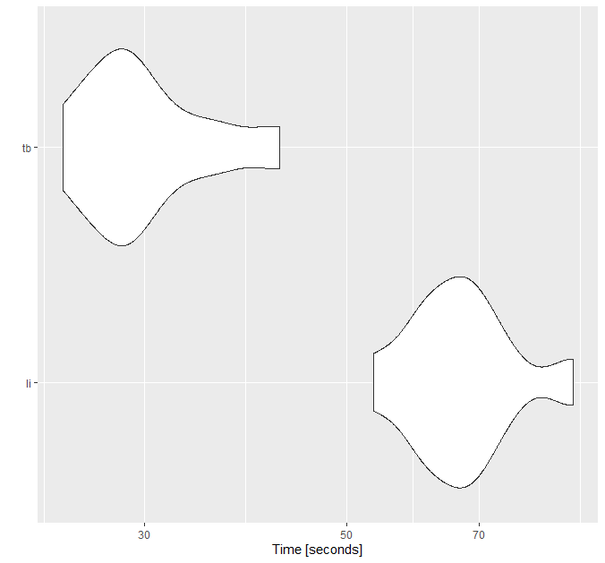

##### 3.4.2.1.2 Multi-Simulation’s first setup’s graph

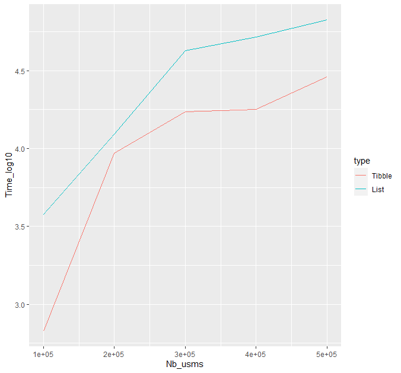

We can see that the Tibble is faster than the List in this first setup.

#### 3.4.2.2 Second setup : 1 DoE, Usms from 100K to 1 Million and 5 Dates

```r
Usms <- c(100000,200000,300000,400000,500000,600000,700000,800000,900000,1000000)
li <- list()
tb <- list()
for (index in Usms) {

  multi_tb <- create_tibble3(USM_list_1996,1,index,sim_data_5)
  multi_li <- create_list2(USM_list_1996,1,index,sim_data_5)

  benchmark_multi <- microbenchmark(li = list_get_usm_names_and_var_values2(multi_li,1,"resmes","1996/01/05"),
                                  tb = tibble_get_usm_names_and_var_values(multi_tb,1,"resmes","1996-01-05"),
                                  times = 100)
  print(benchmark_multi)
  if (index == 100000) {
    li <- summary(benchmark_multi)$median[1]
    tb <- summary(benchmark_multi)$median[2]
  }
  else {
    li <- append(li,summary(benchmark_multi)$median[1])
    tb <- append(tb,summary(benchmark_multi)$median[2])
  }
  print(ggplot2::autoplot(benchmark_multi))
  gc()
}
df <- data.frame(Nb_usms = Usms,Time_log10 = log10(tb), type = "Tibble")
df2 <- data.frame(Nb_usms = Usms,Time_log10 = log10(li), type="List")
final <- rbind(df,df2)
ggplot(final)+geom_line(aes(Nb_usms,Time_log10,colour=type))
```

##### 3.4.2.2.1 Usms = 1M

```r
Unit: milliseconds
 expr        min         lq       mean     median         uq        max neval
   li 11486.8343 11614.7328 11759.9601 11643.0241 11813.4560 18496.4578   100
   tb   110.4579   111.0268   124.1186   115.0654   129.3832   238.7534   100
```

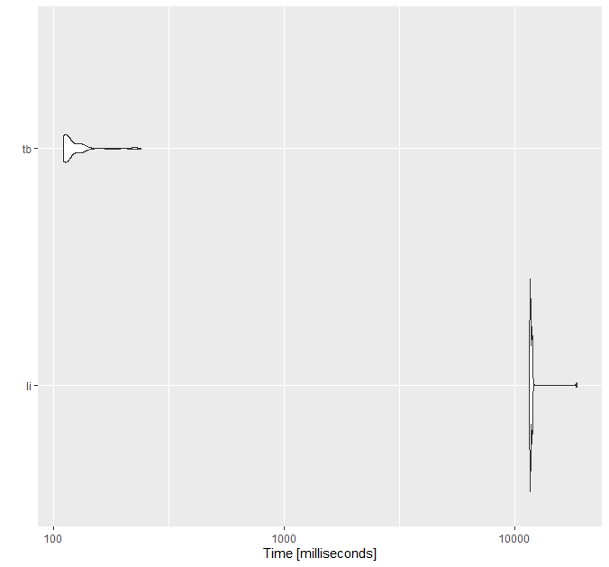

Benchmark Usms = 1M

##### 3.4.2.2.2 Multi-Simulation’s second setup’s graph

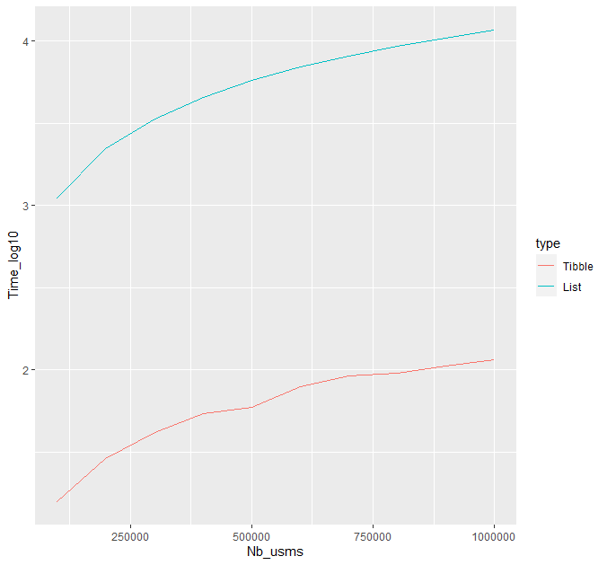

The results on this graph follow the results on the previous one. The Tibble storage method is more adapted to the multi-simulation use case than the List.

We can explain this by the fact that there are more operation done in the List function than in the Tibble function.

### 3.4.3 Analysis’ extraction test

#### 3.4.3.1 First setup : DoE from 10K to 50K, 10 Usms and 289 Dates

```r
DoE <- c(10000,20000,30000,40000,50000)
li <- list()
tb <- list()
for (index in DoE) {

  analysis_tb <- create_tibble3(USM_list_1996,index,10,sim_data_289)
  analysis_li <- create_list2(USM_list_1996,index,10,sim_data_289)

  benchmark_analysis <- microbenchmark(li = list_get_DOE_and_var_values2(analysis_li,"lu96iN6_2","HR_3","1996/01/05"),
                                     tb = tibble_get_DOE_and_var_values(analysis_tb,"lu96iN6_2","HR_3","1996-01-05"),
                                     times = 100)
  print(benchmark_analysis)
  if (index == 10000) {
    li <- summary(benchmark_analysis)$median[1]
    tb <- summary(benchmark_analysis)$median[2]
  }
  else {
    li <- append(li,summary(benchmark_analysis)$median[1])
    tb <- append(tb,summary(benchmark_analysis)$median[2])
  }
  print(ggplot2::autoplot(benchmark_analysis))
  gc()
}
df <- data.frame(DoE_level = DoE,Time_log10 = log10(tb), type = "Tibble")
df2 <- data.frame(DoE_level = DoE,Time_log10 = log10(li), type="List")
final <- rbind(df,df2)
ggplot(final)+geom_line(aes(DoE_level,Time_log10,colour=type))
```

##### 3.4.3.1.1 DoE = 50K

```r
Unit: seconds
 expr      min       lq     mean   median       uq      max neval
   li 1.451001 1.599818 2.545515 2.178224  2.84946 14.13902   100
   tb 1.672656 5.368783 9.237114 9.672728 11.93672 21.91581   100
```

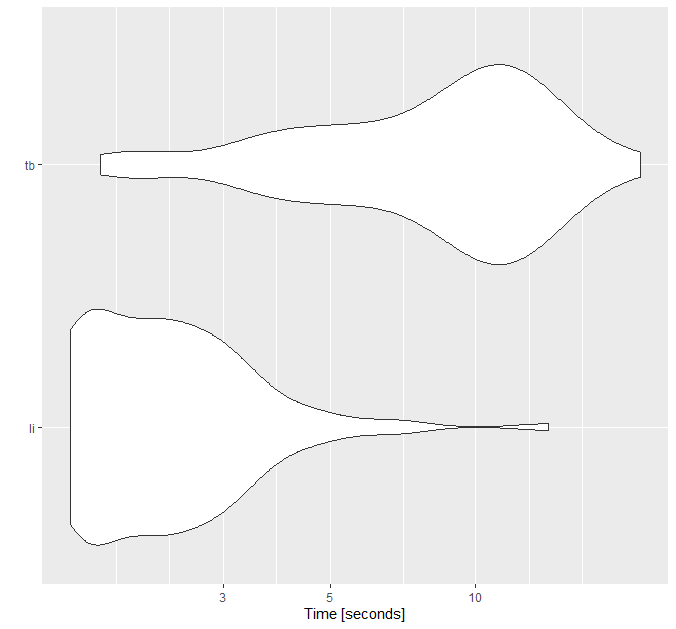

##### 3.4.3.1.2 Analysis’ first setup’s graph

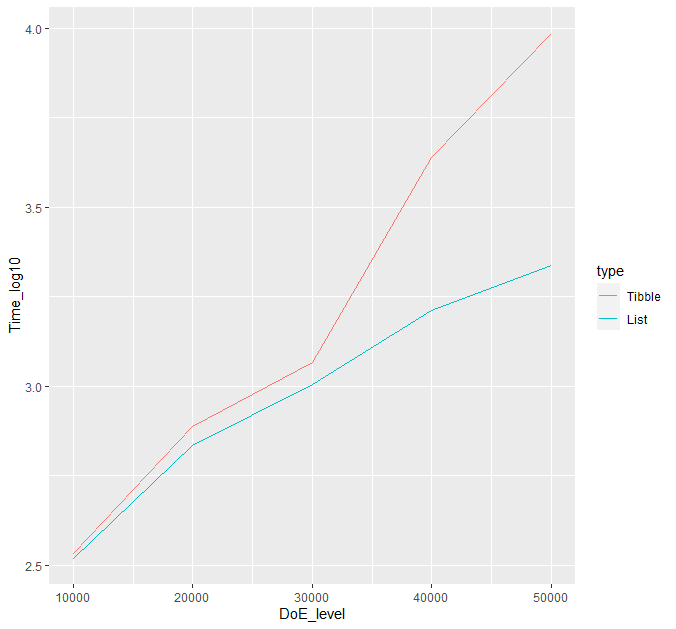

We can see that the List are faster than the Tibble on these tests.

#### 3.4.3.2 Second setup : DoE from 10K to 50K, 10 Usms and 5 Dates

```r
DoE <- c(10000,20000,30000,40000,50000)
li <- list()
tb <- list()
for (index in DoE) {

  analysis_tb <- create_tibble3(USM_list_1996,index,10,sim_data_5)
  analysis_li <- create_list2(USM_list_1996,index,10,sim_data_5)

  benchmark_analysis <- microbenchmark(li = list_get_DOE_and_var_values2(analysis_li,"lu96iN6_2","HR_3","1996/01/05"),
                                     tb = tibble_get_DOE_and_var_values(analysis_tb,"lu96iN6_2","HR_3","1996-01-05"),
                                     times = 100)
  print(benchmark_analysis)
  if (index == 10000) {
    li <- summary(benchmark_analysis)$median[1]
    tb <- summary(benchmark_analysis)$median[2]
  }
  else {
    li <- append(li,summary(benchmark_analysis)$median[1])
    tb <- append(tb,summary(benchmark_analysis)$median[2])
  }
  print(ggplot2::autoplot(benchmark_analysis))
  gc()
}
df <- data.frame(DoE_level = DoE,Time_log10 = log10(tb), type = "Tibble")
df2 <- data.frame(DoE_level = DoE,Time_log10 = log10(li), type="List")
final <- rbind(df,df2)
ggplot(final)+geom_line(aes(DoE_level,Time_log10,colour=type))
```

##### 3.4.3.2.1 DoE = 50K

```r
Unit: milliseconds
 expr      min        lq      mean    median       uq      max neval
   li 572.6908 578.81865 590.97345 582.34080 588.6608 749.8459   100
   tb  41.5272  42.26995  43.26579  42.62525  43.2128  66.4805   100
```

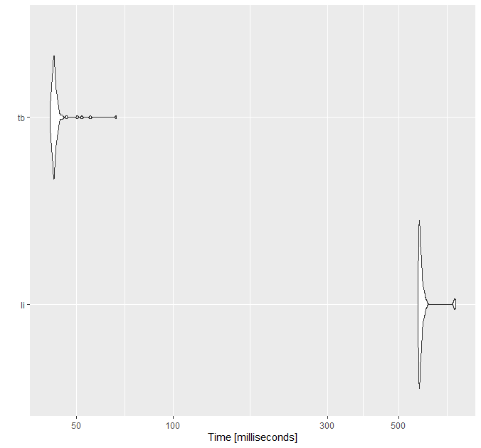

##### 3.4.3.2.2 Analysis’ second setup’s graph

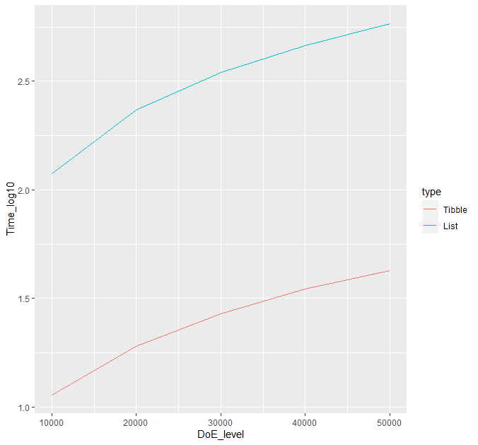

Unlikely to the previous results, this time it’s the Tibble that is faster than the List. We maybe can explain that on the way the dplyr::filter function has been coded. Indeed, in the List function, the wanted Usms are get first, then their variables and values are processed while in the Tibble function, each tibble’s row is tested. And this process takes more time when they are 289 dates per Usm than when they are only 5. We can also conclude that it is faster to search information in a tibble using the dplyr::filter function than in a List.

At the end of these tests, we cannot conclude on which storage method is the most suited because they both had won 3 tests. However, we can say that the Tibble storage method has the advantage because it won more tests on current use of extraction’s functions than the List storage method.

# 4 Annexes

## 4.1 Optimization first setup

### 4.1.1 DoE = 1

```r
Unit: microseconds
 expr   min     lq    mean median    uq    max neval
   li   8.6   9.15  26.174   9.85  10.8 1627.2   100
   tb 146.9 148.35 186.381 149.70 151.3 3042.4   100
```

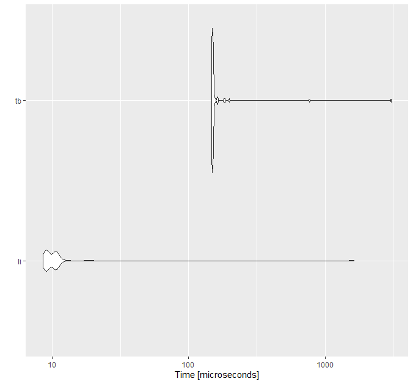

### 4.1.2 DoE = 10K

```r
Unit: microseconds
 expr      min       lq       mean   median       uq      max neval
   li      8.4     10.2     15.713     18.0     20.4     48.9   100
   tb 115675.8 118056.6 132426.305 119287.1 137102.6 370864.7   100
```

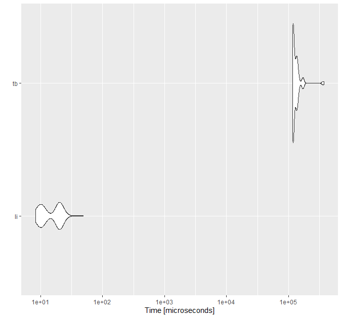

### 4.1.3 DoE = 20K

```r
Unit: microseconds
 expr      min        lq       mean    median       uq      max neval
   li      8.7      9.85     15.714     15.45     20.6     39.8   100
   tb 232682.4 235542.55 266596.692 237526.95 267068.4 797732.5   100
```

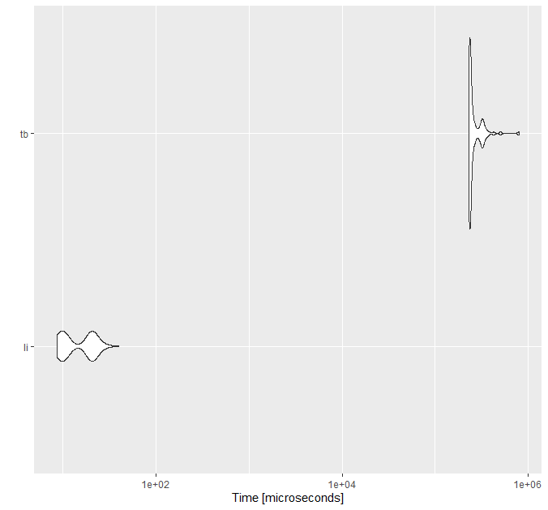

### 4.1.4 DoE = 30K

```r
Unit: microseconds
 expr      min        lq       mean    median        uq       max neval
   li      8.6     10.15     16.659     17.05     21.55      33.7   100
   tb 350982.7 355311.30 426618.585 358406.30 382779.05 2304141.1   100
```

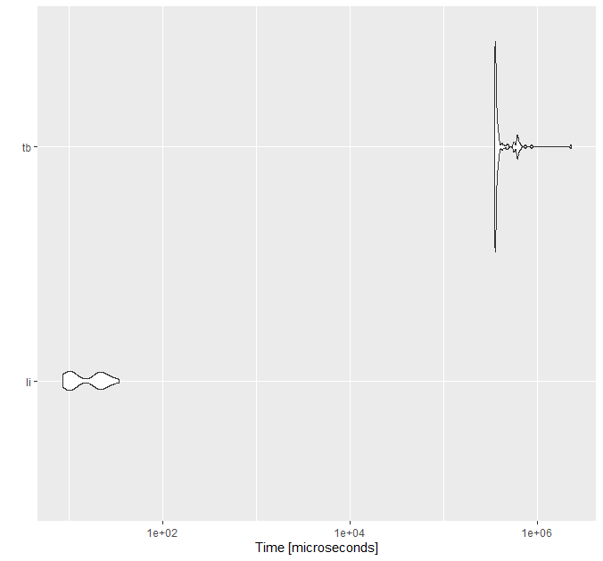

### 4.1.5 DoE = 40K

```r
Unit: microseconds
 expr        min         lq         mean      median          uq         max neval
   li      8.701      9.951     17.90196     11.8505     24.0015      67.901   100
   tb 471800.101 477465.601 625643.11201 500534.1510 520438.0510 4024280.902   100
```

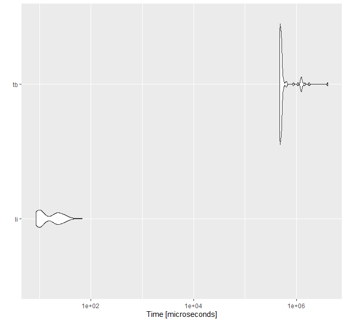

## 4.2 Optimization second setup

### 4.2.1 DoE = 1

```r
Unit: microseconds
 expr   min      lq      mean   median       uq      max neval
   li   9.4   9.901  27.33004  11.0005  11.5015 1660.500   100
   tb 127.8 130.001 171.84004 131.4010 133.3015 3208.001   100
```

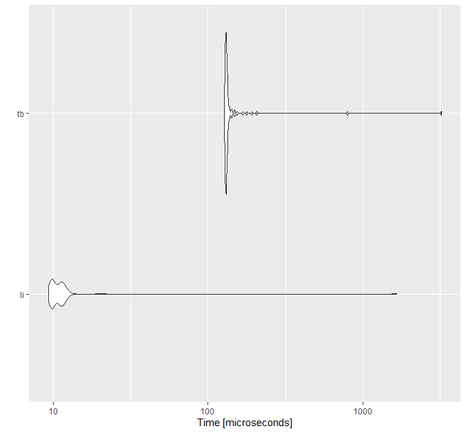

### 4.2.2 DoE = 10K

```r
Unit: microseconds
 expr     min       lq        mean    median        uq        max neval
   li     9.2    10.80    16.45996    17.551    21.201     57.802   100
   tb 78492.8 80416.95 91989.21306 82492.951 97015.701 295939.901   100
```

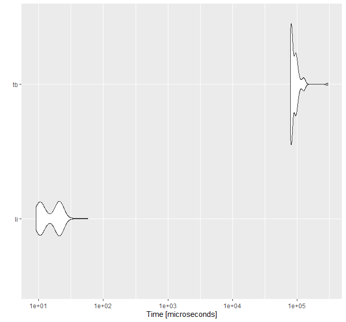

### 4.2.3 DoE = 20K

```r
Unit: microseconds
 expr        min          lq         mean      median          uq        max neval
   li      9.101     10.3015     16.02597     15.6505     21.1005     29.401   100
   tb 158601.201 161007.1510 182001.90508 162804.0010 183789.4015 454152.201   100
```

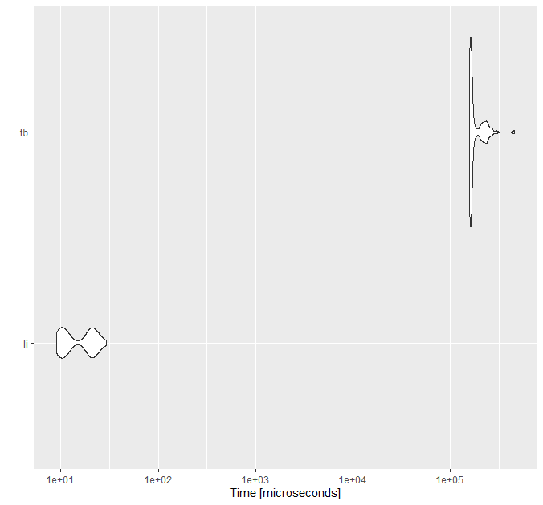

### 4.2.4 DoE = 30K

```r
Unit: microseconds
 expr        min         lq         mean      median         uq         max neval
   li      9.602     10.801     16.53806     16.3515     21.651      29.301   100
   tb 238471.001 242476.151 288057.92298 246753.6010 295745.701 1030967.502   100
```

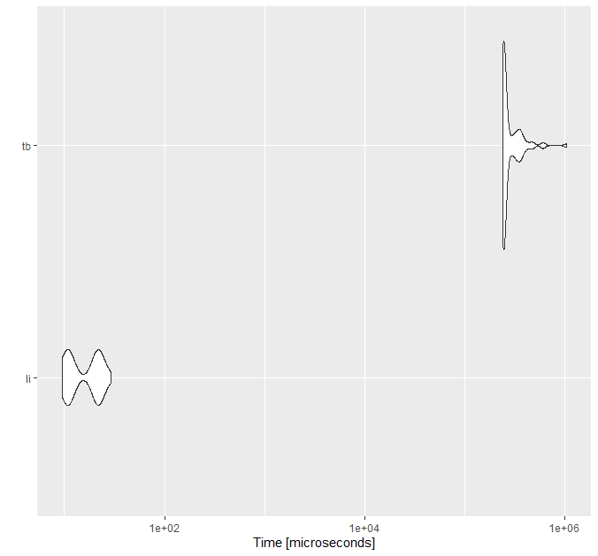

### 4.2.5 DoE = 40K

```r
Unit: microseconds
 expr        min          lq        mean      median         uq         max neval
   li      9.201     10.3515     17.4849     12.4515     21.901      94.401   100
   tb 320708.502 324527.1005 380501.9410 329340.0005 351341.650 1022214.702   100
```

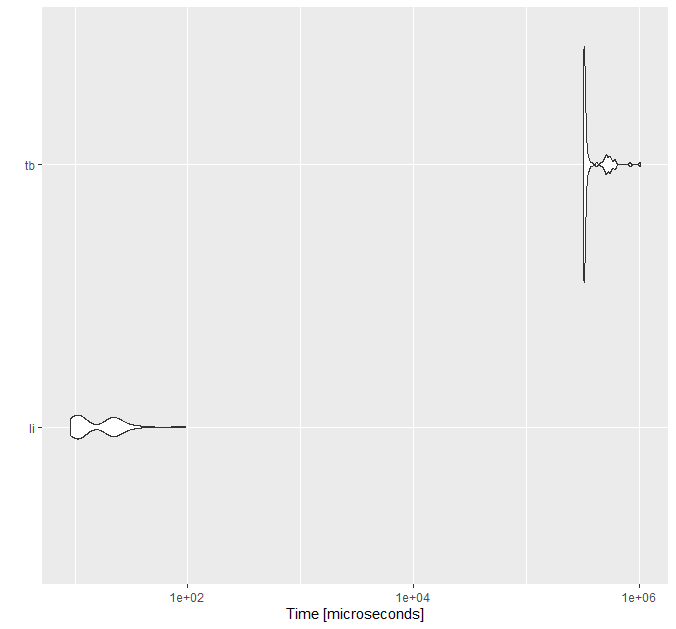

## 4.3 Multi-Simulation first setup

### 4.3.1 Usms = 100K

```r
Unit: milliseconds
 expr       min        lq      mean   median       uq      max neval
   li 3379.0889 3579.2486 4018.0930 3790.463 4421.053 5221.642    10
   tb  541.0025  553.7962  856.7428  673.626 1249.987 1272.214    10
```

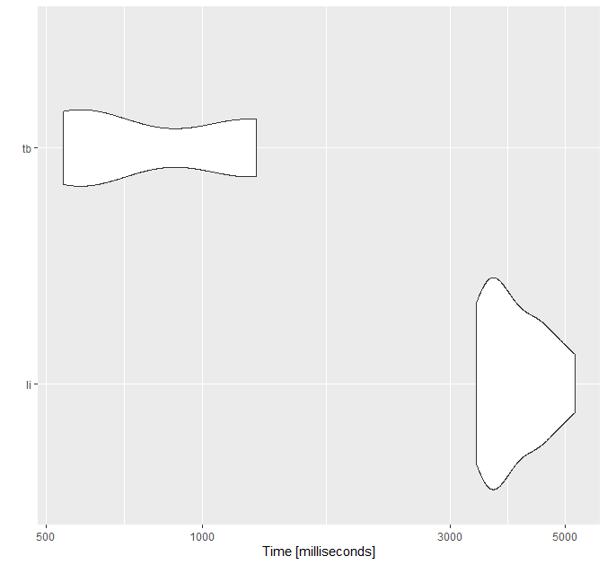

### 4.3.2 Usms = 200K

```r
Unit: seconds
 expr      min        lq      mean   median       uq      max neval
   li 9.875949 11.733033 13.412941 12.35984 12.89953 23.13303    10
   tb 1.246529  4.580581  7.933174  9.30585 11.43183 12.57116    10
```

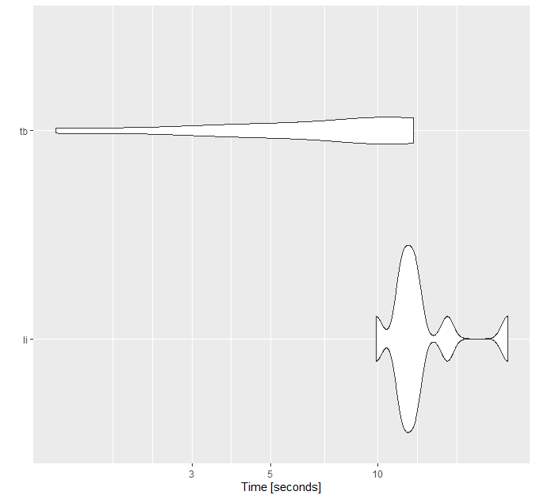

### 4.3.3 Usms = 300K

```r
Unit: seconds
 expr       min       lq     mean   median       uq      max neval
   li 34.724345 39.25414 43.24640 42.37673 42.92145 63.07541    10
   tb  9.739061 14.45071 17.96186 17.18580 19.08316 29.95370    10
```

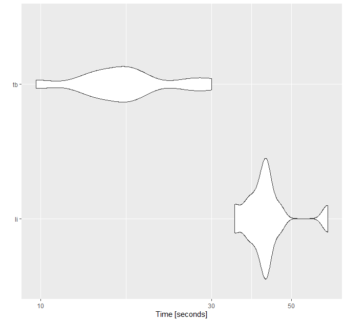

### 4.3.4 Usms = 400K

```r
Unit: seconds
 expr      min       lq     mean   median       uq      max neval
   li 48.00497 48.88886 53.82465 51.82287 59.84124 64.32469    10
   tb 14.45660 17.04424 18.42664 17.80213 18.67832 24.64189    10
```

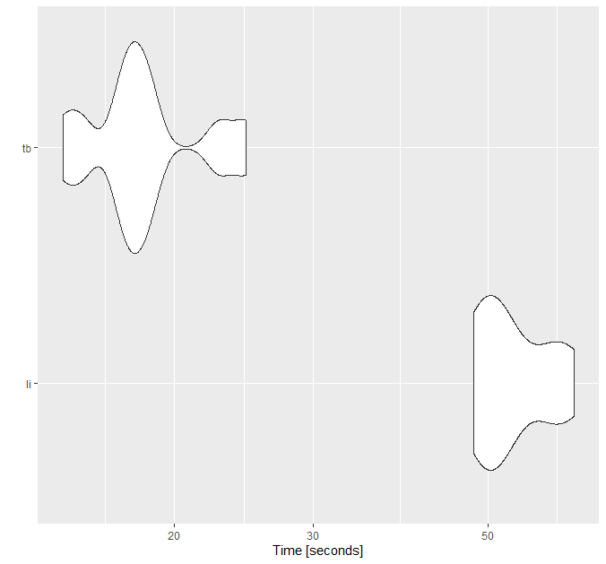

## 4.4 Multi-Simulation second setup

### 4.4.1 Usms = 100K

```r
Unit: milliseconds
 expr       min         lq       mean     median       uq       max neval
   li 1088.0238 1102.16540 1116.10545 1106.70015 1113.650 1329.0294   100
   tb   14.5051   14.93445   16.03744   15.80405   16.586   25.7652   100
```

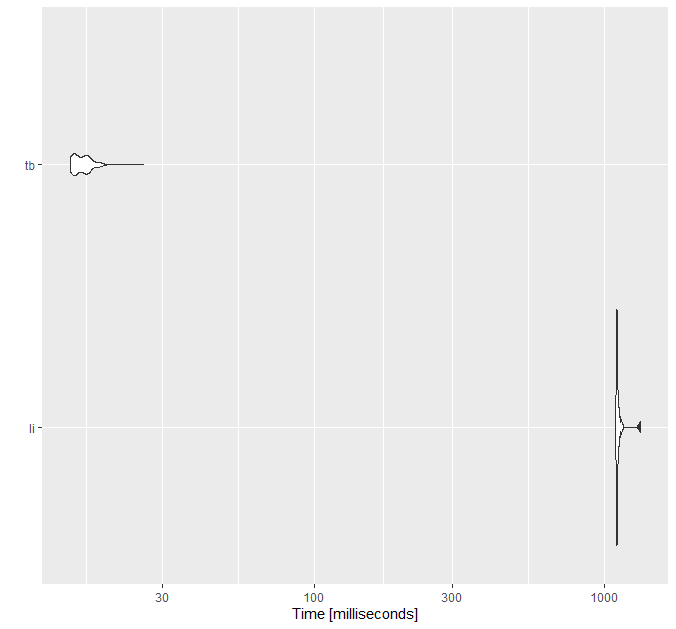

### 4.4.2 Usms = 200K

```r
Unit: milliseconds
 expr       min         lq       mean    median        uq       max neval
   li 2150.3295 2207.03225 2232.33302 2217.5643 2242.5016 2432.7997   100
   tb   22.1346   25.65535   27.78092   28.6569   29.2289   37.4738   100
```

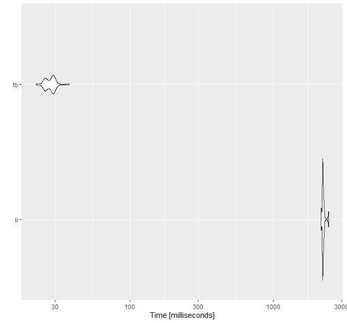

### 4.4.3 Usms = 300K

```r
Unit: milliseconds
 expr       min        lq       mean     median         uq       max neval
   li 3244.9939 3333.1485 3384.11247 3354.21600 3383.37670 3639.4534   100
   tb   36.4825   41.2495   42.00873   41.56275   42.19875   57.5007   100
```

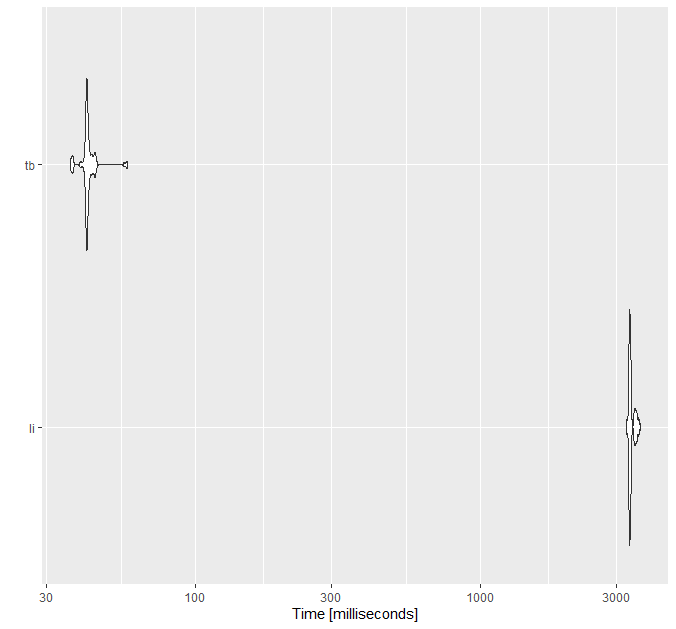

### 4.4.4 Usms = 400K

```r
Unit: milliseconds
 expr       min        lq       mean    median         uq       max neval
   li 4410.2640 4468.7386 4567.79492 4511.5391 4657.77315 4873.1753   100
   tb   49.6277   53.4986   58.25138   54.2582   55.64305  120.5135   100
```

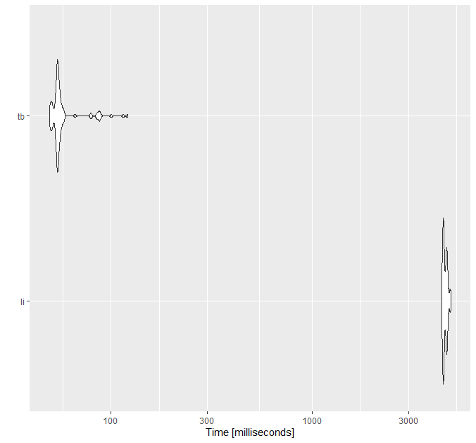

### 4.4.5 Usms = 500K

```r
Unit: milliseconds
 expr       min        lq       mean    median        uq       max neval
   li 5528.8481 5632.9156 5722.78715 5755.9341 5805.1352 5988.5920   100
   tb   54.9231   57.8324   65.91874   59.1574   63.1149  117.1691   100
```

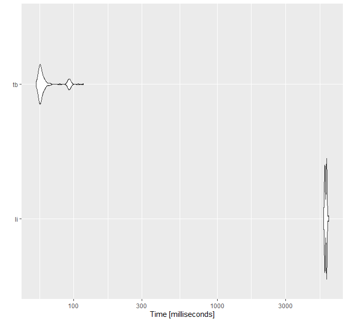

### 4.4.6 Usms = 600K

```r
Unit: milliseconds
 expr       min         lq       mean     median         uq       max neval
   li 6689.3458 6921.03705 6950.86080 6937.67395 6961.27875 7157.0283   100
   tb   66.8157   68.89395   83.82181   79.15155   83.51865  137.0235   100
```

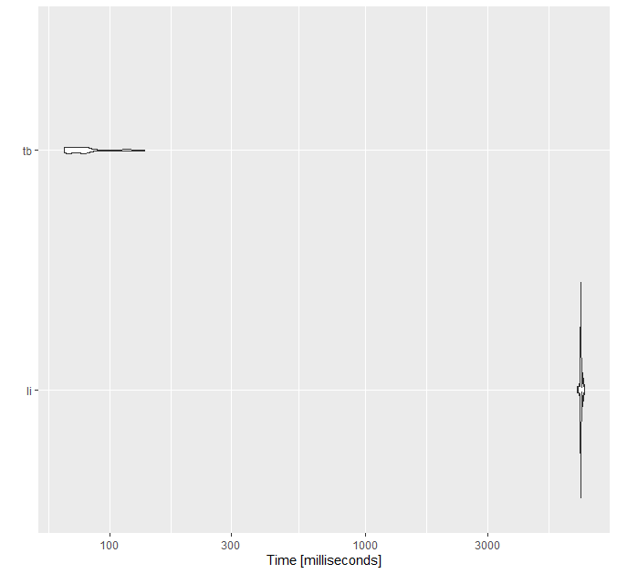

### 4.4.7 Usms = 700K

```r
Unit: milliseconds
 expr       min        lq      mean     median         uq       max neval
   li 7929.3581 8036.8161 8098.1972 8071.81925 8150.75185 8303.9721   100
   tb   77.6896   87.2805   97.8486   92.06255   95.33865  155.3712   100
```

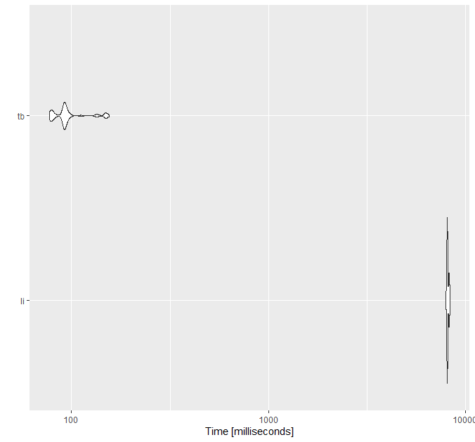

### 4.4.8 Usms = 800K

```r
Unit: milliseconds
 expr       min         lq      mean     median        uq       max neval
   li 9066.5991 9219.86695 9292.1561 9254.79895 9377.0507 9645.0329   100
   tb   89.2994   90.77525  103.9797   95.43965  106.9173  203.0872   100
```

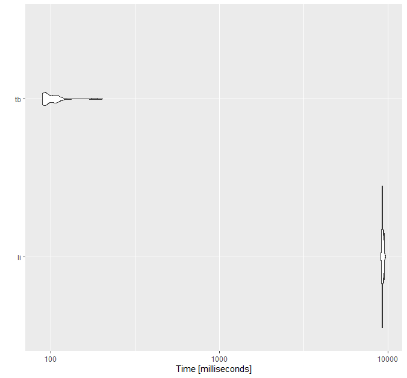

### 4.4.9 Usms = 900K

```r
Unit: milliseconds
 expr        min         lq       mean     median         uq        max neval
   li 10308.5815 10419.0956 10491.5827 10458.4316 10527.7029 11640.7302   100
   tb   100.3078   100.9002   113.9623   105.3276   118.3651   210.0611   100
```

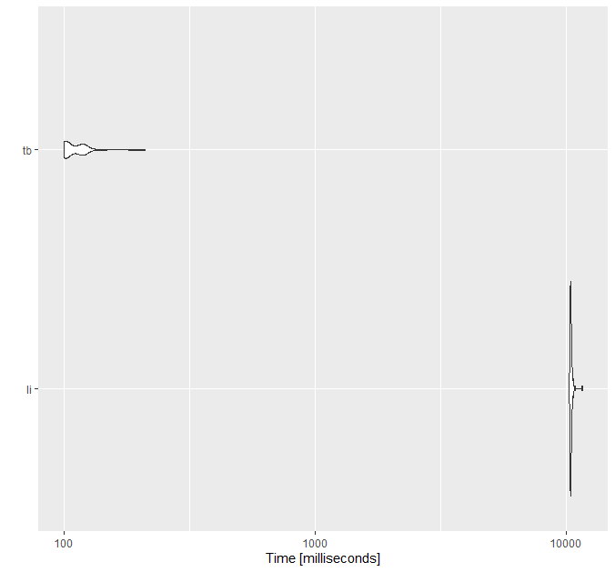

## 4.5 Analysis first setup

### 4.5.1 DoE = 10K

```r
Unit: milliseconds
 expr      min       lq     mean   median       uq      max neval
   li 282.6968 293.9241 339.3505 330.6117 369.7605 582.6753   100
   tb 333.5801 336.8654 374.8506 340.2402 353.6569 757.5860   100
```

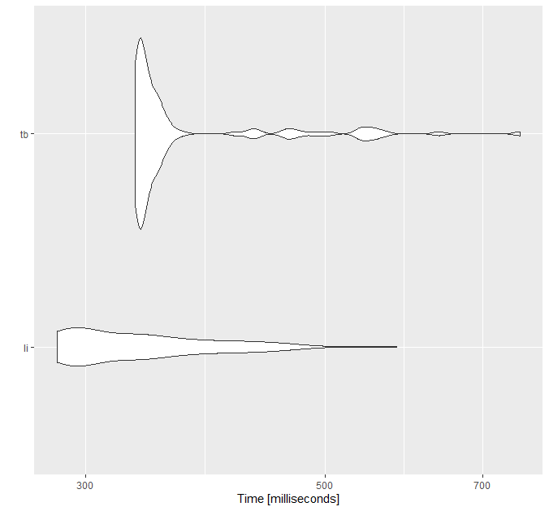

### 4.5.2 DoE = 20K

```r
Unit: milliseconds
 expr     min       lq     mean   median       uq      max neval
   li 574.423 596.6466 742.7338 682.8537 844.5368 1417.813   100
   tb 664.707 721.9076 827.1570 772.0500 806.6606 2102.566   100
```

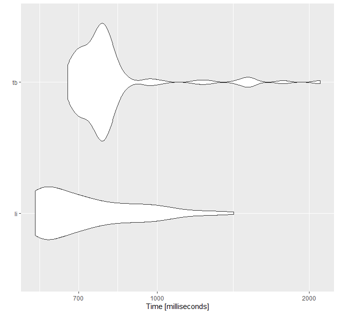

```r
Unit: milliseconds
 expr       min        lq     mean   median      uq      max neval
   li  853.7841  893.7934 1134.345 1007.887 1225.57 2283.683   100
   tb 1005.3673 1096.2543 1580.385 1163.499 1585.62 6333.897   100
```

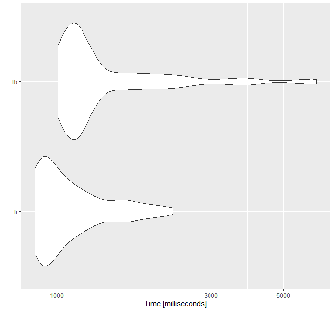

```r
Unit: seconds
 expr     min       lq     mean   median       uq       max neval
   li 1.15955 1.277410 1.824324 1.625104 2.103056  4.902927   100
   tb 1.48281 2.351267 5.390992 4.366776 6.793934 24.125125   100
```

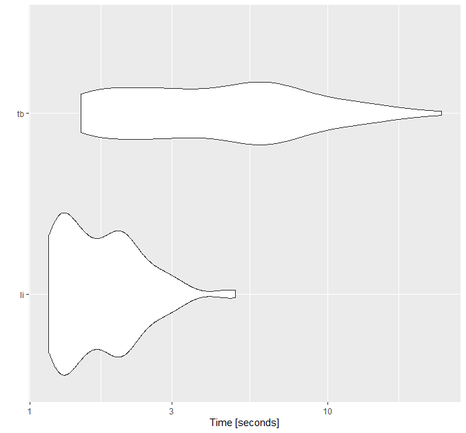

## 4.6 Analysis second setup

### 4.6.1 DoE = 10K

```r
Unit: milliseconds
 expr     min       lq      mean    median       uq      max neval
   li 111.151 115.9031 120.12383 118.62490 120.5802 258.1678   100
   tb  10.478  11.0022  11.91204  11.37195  11.6097  25.5061   100
```

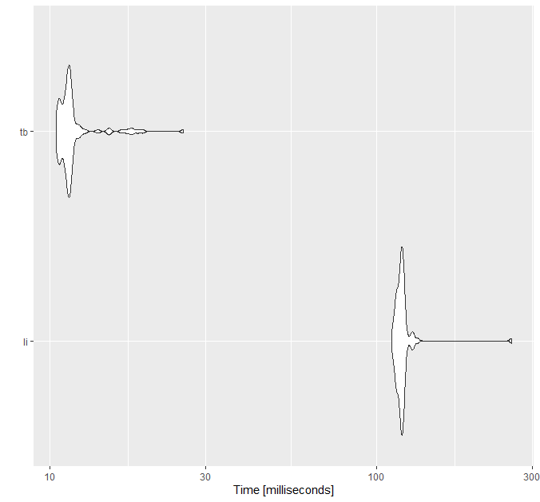

### 4.6.2 DoE = 20K

```r
Unit: milliseconds
 expr      min       lq      mean   median       uq      max neval
   li 224.6706 229.3868 234.99459 233.5398 236.5246 387.2867   100
   tb  18.6105  18.8324  21.23352  19.0604  19.3574 179.9424   100
```

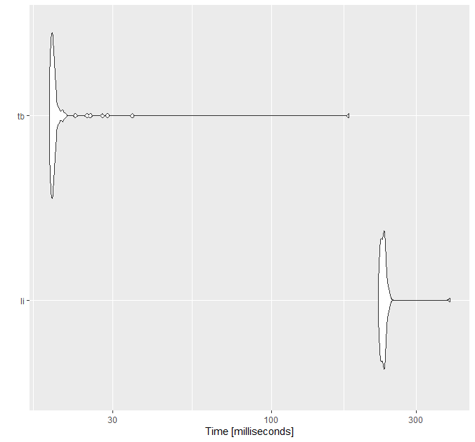

```r
Unit: milliseconds
 expr      min       lq      mean   median       uq      max neval
   li 337.3563 344.8231 357.99463 347.2255 352.0751 501.4782   100
   tb  26.2836  26.7208  28.32191  26.9891  27.4553  46.1429   100
```

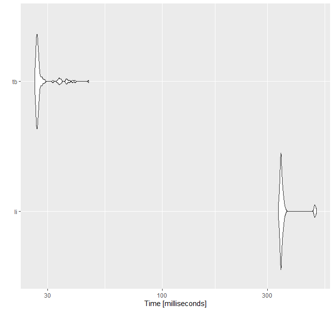

```r
Unit: milliseconds
 expr      min       lq      mean   median        uq      max neval
   li 448.5105 458.7205 468.55195 463.1826 469.84395 625.1621   100
   tb  33.8663  34.4889  35.47545  34.8803  35.30425  55.3542   100
```

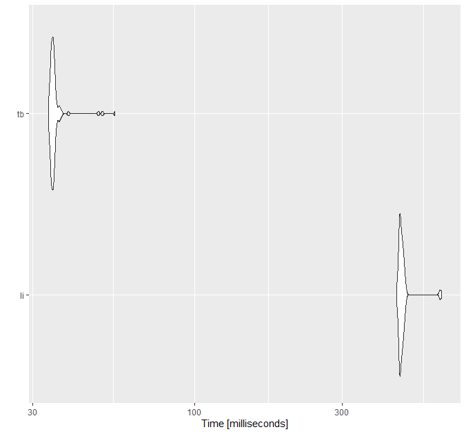